# PS05-markdown-basic-plots Gapminder Data Analysis

Yixian He

2023-02-21

## **1 Load and check data**

You first task is to do a very simple data check:  
1. (1pt) For solving the problems, and answering the questions, create a new rmarkdown document with an appropriate title.

```r
getwd()
```

```
## [1] "C:/Users/think/Documents/Academics/INFO201/ps05-markdown-basic-plot/INFO201-PS5-markdown-basic-plots"
```

```r
library(reader)
## Load data
gapminder <- read.delim("gapminder.csv")
sum(is.na(gapminder))
```

```
## [1] 103406
```

2. (2pt) Load data. How many rows/columns do we have?

```r
## Rows and columns of the data
nrow(gapminder)
```

```
## [1] 13055
```

```r
ncol(gapminder)
```

```
## [1] 25
```

*There is 13055 rows and 25 columns in the data.*

3. (2pt) Print a small sample of data. Does it look OK?

```r
## Print a small sample of the data
head(gapminder)
```

```
##   iso3  name iso2   region                      sub.region intermediate.region
## 1  ABW Aruba   AW Americas Latin America and the Caribbean           Caribbean
## 2  ABW Aruba   AW Americas Latin America and the Caribbean           Caribbean
## 3  ABW Aruba   AW Americas Latin America and the Caribbean           Caribbean
## 4  ABW Aruba   AW Americas Latin America and the Caribbean           Caribbean
## 5  ABW Aruba   AW Americas Latin America and the Caribbean           Caribbean
## 6  ABW Aruba   AW Americas Latin America and the Caribbean           Caribbean
##   time totalPopulation fertilityRate lifeExpectancy childMortality
## 1 1960           54211         4.820         65.662             NA
## 2 1961           55438         4.655         66.074             NA
## 3 1962           56225         4.471         66.444             NA
## 4 1963           56695         4.271         66.787             NA
## 5 1964           57032         4.059         67.113             NA
## 6 1965           57360         3.842         67.435             NA
##   youthFemaleLiteracy youthMaleLiteracy adultLiteracy GDP_PC accessElectricity
```

[output cut: 20 more lines]

## **2 Descriptive statistics**

1. (3pt) How many countries are there in the dataset? Analyze all three: iso3, iso2 and name.

```r
## Load dplyr
library(dplyr)
## Count unique countries by iso3 code
n_distinct(gapminder$iso3)
```

```
## [1] 253
```

```r
## Count unique countries by iso2 code
n_distinct(gapminder$iso2)
```

```
## [1] 249
```

```r
## Count unique countries by name
n_distinct(gapminder$name)
```

```
## [1] 250
```

*For iso3 code, there are 253 countries.*  
*For iso2 code, there are 249 countries.*  
*For name, there are 250 countries.*

2. If you did this correctly, you saw that there are more names than iso-2 codes, and there are even more iso3 -codes. What is going on? Can you find it out?

*The single iso-2 codes and iso-3 code may correspond to same countries.*

1. (5pt) Find how many names are there for each iso-2 code. Are there any iso-2 codes that correspond to more than one name? What are these countries?

```r
library(dplyr)

iso2count <- gapminder %>%
  group_by(iso2) %>%
  filter(!is.na(name)) %>%
  summarize(num = n_distinct(name)) %>%
  filter(num > 1)


iso2count
```

```
## # A tibble: 1 × 2
##   iso2    num
##   <chr> <int>
## 1 ""        2
```

2. (5pt) Now repeat the same for name and iso3-code. Are there country names that have more than one iso3-code? What are these countries? Hint: two of these entitites are CHANISL and NLD CURACAO.

```r
iso3count <- gapminder %>%
  group_by(name) %>%
  summarize(num = n_distinct(iso3)) %>%
  arrange(desc(num))
iso3count
```

```
## # A tibble: 250 × 2
##    name                    num
##    <chr>                 <int>
##  1 ""                        4
##  2 "Afghanistan"             1
##  3 "Albania"                 1
##  4 "Algeria"                 1
##  5 "American Samoa"          1
##  6 "Andorra"                 1
##  7 "Angola"                  1
##  8 "Anguilla"                1
##  9 "Antarctica"              1
## 10 "Antigua and Barbuda"     1
## # … with 240 more rows
```

*There is 4 values which means there is no country appears more than once.*

3. (2pt) What is the minimum and maximum year in these data?

```r
min_year <- min(gapminder$time, na.rm = TRUE)
max_year <- max(gapminder$time, na.rm = TRUE)

min_year
```

```
## [1] 1960
```

```r
max_year
```

```
## [1] 2019
```

*The minimum year is 1960 and the maximum year is 2019.*

## **3 CO2 emissions**

Next, let’s analyze CO2 emissions.

1. (2pt) How many missing co2 emissions are there for each year? Analyze both missing CO2 and co2_PC. Which years have most missing data?

```r
library(dplyr)
co2_missing <- gapminder %>%
  group_by(time) %>%
  summarize(num_missing = sum(is.na(co2)),
            num_missing_PC = sum(is.na(co2_PC))) %>%
  arrange(desc(num_missing))
co2_missing
```

```
## # A tibble: 61 × 3
##     time num_missing num_missing_PC
##    <int>       <int>          <int>
##  1  2017         217            217
##  2  2018         217            217
##  3  2019         217            217
##  4  1960          60             60
##  5  1961          60             60
##  6  1962          58             58
##  7  1963          57             57
##  8  1964          51             51
##  9  1965          51             51
## 10  1966          51             51
## # … with 51 more rows
```

2. (5pt) Make a plot of total CO2 emissions over time for the U.S, China, and India. Add a few more countries of your choice. Explain what do you see.

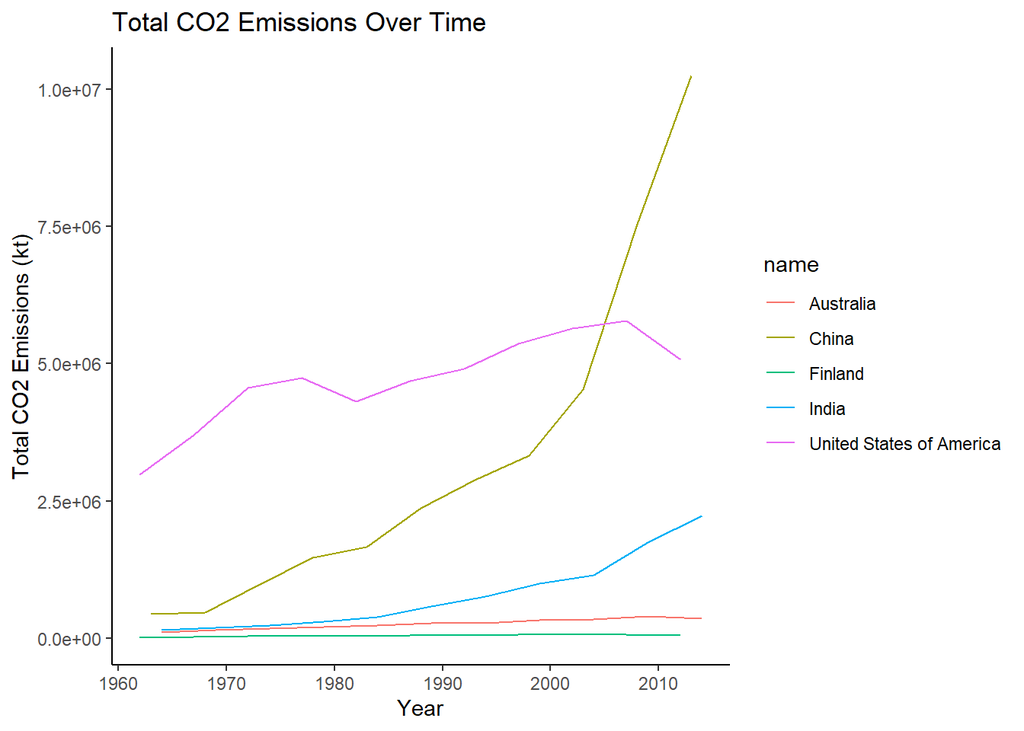

```r
library(ggplot2)
library(dplyr)
selected_countries <- c("United States of America", "China", "India", "Australia", "Finland")

co2_over_time <- gapminder %>%
  filter(name == selected_countries) %>%
  filter(!is.na(co2))


ggplot(co2_over_time, aes(x = time, y = co2, color = name, group = name)) +
  geom_line() +
  ggtitle("Total CO2 Emissions Over Time") +
  xlab("Year") +
  ylab("Total CO2 Emissions (kt)") +
  theme_classic()
```

*China has the highest CO2 emissions, which rose exponentially between 2000 and 2010. USA’s CO2 emissions were surpassed by China’s between 2000 and 2010, after having been the highest emitter.*

3. (5pt) Now let’s analyze the CO2 emissions per capita (co2_PC). Make a similar plot of the same countries. What does this figure suggest?

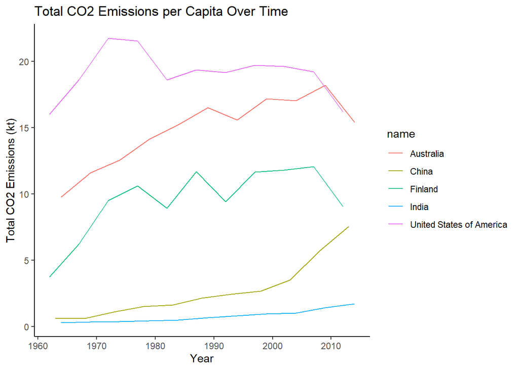

```r
library(ggplot2)
library(dplyr)
selected_countries <- c("United States of America", "China", "India", "Australia", "Finland")

co2_PC_over_time <- gapminder %>%
  filter(name == selected_countries) %>%
  filter(!is.na(co2_PC))


ggplot(co2_PC_over_time, aes(x = time, y = co2_PC, color = name, group = name)) +
  geom_line() +
  ggtitle("Total CO2 Emissions per Capita Over Time") +
  xlab("Year") +
  ylab("Total CO2 Emissions (kt)") +
  theme_classic()
```

*US has the highest CO2 emissions per capita, followed by Australia and then Finland. These three countries are developed countries with higher economic levels, while China and India are developing countries with lower economic levels and lower CO2 emissions per capita.*

4. (6pt) Compute average CO2 emissions per capita across the continents (assume region is the same as continent). Comment what do you see.  
   Note: just compute averages over countries and ignore the fact that countries are of different size. Hint: Americas 2016 should be 4.80.

```r
library(dplyr)
co2_per_capita <- gapminder %>%
  group_by(region) %>%
  summarize(average_co2_per_capita = mean(co2_PC, na.rm = TRUE))
co2_per_capita
```

```
## # A tibble: 6 × 2
##   region     average_co2_per_capita
##   <chr>                       <dbl>
## 1 ""                         16.2
## 2 "Africa"                    0.930
## 3 "Americas"                  6.46
## 4 "Asia"                      6.21
## 5 "Europe"                    7.95
## 6 "Oceania"                   4.39
```

*The per capita CO2 emissions vary greatly by continent, with Europe having the highest per capita CO2 emissions first, followed by the Americas and Asia, and finally Oceania and Africa. The level of CO2 emissions may be due to different factors, such as economic development, energy sources, and the degree of industrialization.*

5. (7pt) Make a barplot where you show the previous results–average CO2 emissions per capita across continents in 1960 and 2016.

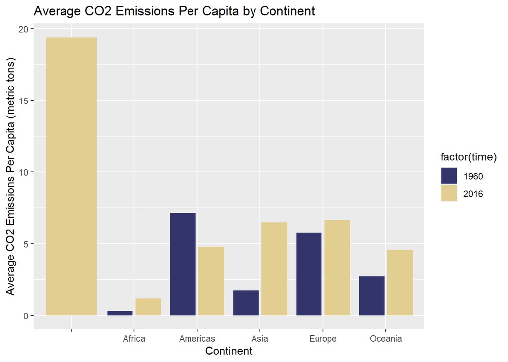

```r
library(dplyr)
library(ggplot2)

# Remove rows with missing values for co2_PC
avg_co2_PC <- gapminder %>%
  filter(!is.na(co2_PC), time %in% c(1960, 2016)) %>%
  group_by(time,region) %>%
  summarize(avg_co2_pc = mean(co2_PC))
# Create bar plot
ggplot(avg_co2_PC, aes(x = region, y = avg_co2_pc, fill = factor(time)))+
  geom_col(position = "dodge2") +
  labs(title = "Average CO2 Emissions Per Capita by Continent",
       x = "Continent",
       y = "Average CO2 Emissions Per Capita (metric tons)") +
  scale_fill_manual(values = c("#33346a", "#e2ce90"),
                    labels = c("1960", "2016"))
```

6. Which countries are the three largest, and three smallest CO2 emitters (in terms of CO2 per capita) in 2019 for each continent? (Assume region is continent).

```r
library(dplyr)

co2_2019 <- gapminder %>%
  filter(time == 2019)

co2_by_country_continent <- co2_2019 %>%
  group_by(region, sub.region) %>%
  summarise(avg_co2_pc = mean(co2_PC, na.rm = TRUE)) %>%
  ungroup()
co2_top_bottom <- co2_by_country_continent %>%
  group_by(region) %>%
  slice_max(order_by = avg_co2_pc, n = 3) %>%
  bind_rows(co2_by_country_continent %>%
              group_by(region) %>%
              slice_min(order_by = avg_co2_pc, n = 3)) %>%
  arrange(region, avg_co2_pc)

co2_top_bottom
```

```
## # A tibble: 36 × 3
## # Groups:   region [6]
##    region     sub.region                        avg_co2_pc
##    <chr>      <chr>                                  <dbl>
##  1 ""         ""                                       NaN
##  2 ""         ""                                       NaN
##  3 "Africa"   "Northern Africa"                        NaN
##  4 "Africa"   "Sub-Saharan Africa"                     NaN
##  5 "Africa"   "Northern Africa"                        NaN
##  6 "Africa"   "Sub-Saharan Africa"                     NaN
##  7 "Americas" "Latin America and the Caribbean"        NaN
##  8 "Americas" "Northern America"                       NaN
##  9 "Americas" "Latin America and the Caribbean"        NaN
## 10 "Americas" "Northern America"                       NaN
## # … with 26 more rows
```

## **4 GDP per capita**

Let’s look at GDP per capita (GDP_PC). 1. (8pt) Make a scatterplot of GDP per capita versus life expectancy by country, using data for 1960. Make the point size dependent on the country size, and color those according to the continent. Feel free to adjust the plot in other ways to make it better. Comment what do you see there.

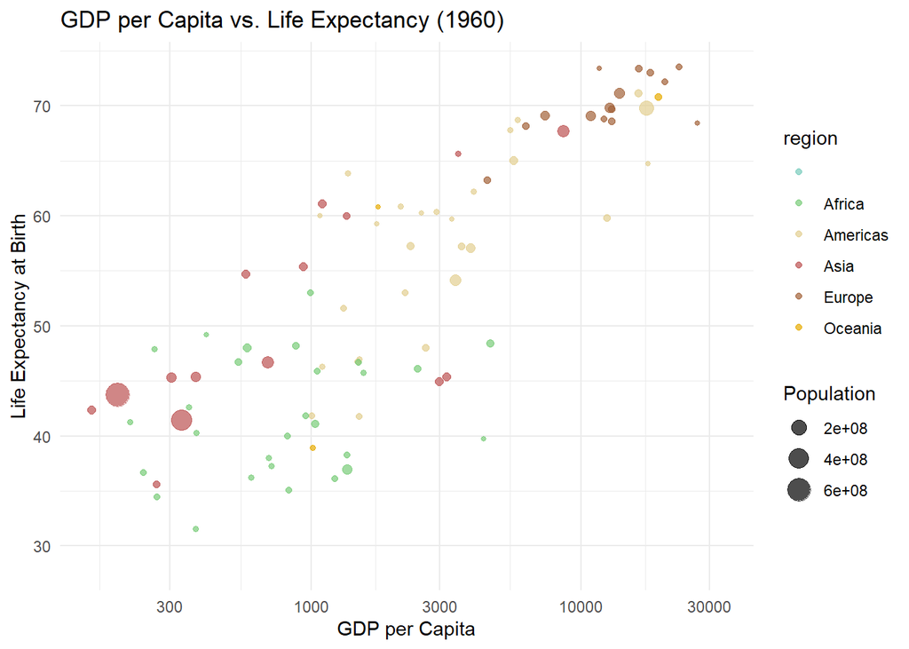

```r
library(dplyr)
library(ggplot2)

# Filter data for 1960
gdp_life_exp_1960 <- gapminder %>% filter(time == 1960)

# Create scatterplot of GDP per capita versus life expectancy by country, with point size and color by continent
ggplot(gdp_life_exp_1960, aes(x = GDP_PC, y = lifeExpectancy, size = totalPopulation, color = region)) +
  geom_point(alpha = 0.7) +
  scale_x_log10() +
  labs(title = "GDP per Capita vs. Life Expectancy (1960)",
       x = "GDP per Capita",
       y = "Life Expectancy at Birth",
       size = "Population") +
  scale_color_manual(values = c("#78cbbc", "#78cb78", "#e2ce90", "#bc5151", "#a26138", "#e6ab02")) +
  theme_minimal()
```

*There is a positive correlation between life expectancy and GDP per capita,richer countries tend to have higher life expectancy. We can also see that African countries tend to have lower GDP per capita and lower life expectancy.*

2. (4pt) Make a similar plot, but this time use 2019 data only.

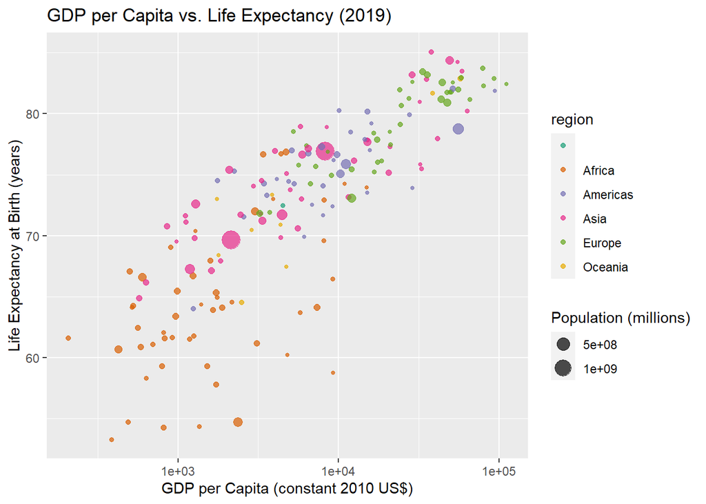

```r
# Filter data for 2019
gdp_life_exp_2019 <- gapminder %>% filter(time == 2019)

# Create scatterplot of GDP per capita versus life expectancy by country, with point size and color by continent
ggplot(gdp_life_exp_2019, aes(x = GDP_PC, y = lifeExpectancy, size = totalPopulation, color = region)) +
  geom_point(alpha = 0.7) +
  scale_x_log10() +
  labs(title = "GDP per Capita vs. Life Expectancy (2019)",
       x = "GDP per Capita (constant 2010 US$)",
       y = "Life Expectancy at Birth (years)",
       size = "Population (millions)") +
  scale_color_manual(values = c("#1b9e77", "#d95f02", "#7570b3", "#e7298a", "#66a61e", "#e6ab02"))
```

3. (6pt) Compare these two plots and comment what do you see. How has world developed through the last 60 years? *By comparing the plots of 1960 and 2019,in 1960,European and North American countries had higher life expectancy and GDP per capita, while African and Asian countries had lower values.*

*In 2019, these points are less dispersed and the separation between continents is less pronounced. GDP per capita and life expectancy still show a positive correlation.*

4. (6pt) Compute the average life expectancy for each continent in 1960 and 2019. Do the results fit with what do you see on the figures?

```r
library(dplyr)
avg_life_expectancy_1960 <- gapminder %>%
  filter(time == 1960) %>%
  group_by(region) %>%
  summarise(avg_life_expectancy_1960 = mean(lifeExpectancy, na.rm = TRUE))

avg_life_expectancy_1960
```

```
## # A tibble: 6 × 2
##   region     avg_life_expectancy_1960
##   <chr>                         <dbl>
## 1 ""                             70.7
## 2 "Africa"                       41.5
## 3 "Americas"                     58.6
## 4 "Asia"                         51.6
## 5 "Europe"                       68.3
## 6 "Oceania"                      56.4
```

```r
library(dplyr)

avg_life_expectancy_2019 <- gapminder %>%
  filter(time == 2019) %>%
  group_by(region) %>%
  summarize(avg_life_expectancy_2019 = mean(lifeExpectancy, na.rm = TRUE))

avg_life_expectancy_2019
```

```
## # A tibble: 6 × 2
##   region     avg_life_expectancy_2019
##   <chr>                         <dbl>
## 1 ""                             77.8
## 2 "Africa"                       64.1
## 3 "Americas"                     75.8
## 4 "Asia"                         74.6
## 5 "Europe"                       79.4
## 6 "Oceania"                      73.5
```

*There is a overall increase in average life expectancy, which accord with the scatter plot.This may result from the development of economy.*

5. (8pt) Compute the average LE growth from 1960-2019 across the continents. Show the results in the order of growth. Explain what do you see. Hint: these data (data in long form) is not the simplest to compute growth. But you may want to check out the lag() function. And do not forget to group data by continent when using lag(), otherwise your results will be messed up!

```r
library(dplyr)
avg_le_growth <- gapminder %>%
  filter(time %in% c(1960, 2019)) %>%
  group_by(region) %>%
  mutate(le_diff = lifeExpectancy - lag(lifeExpectancy)) %>%
  filter(time == 2019) %>%
  summarize(avg_le_growth = mean(le_diff, na.rm = TRUE)) %>%
  arrange(desc(avg_le_growth))

avg_le_growth
```

```
## # A tibble: 6 × 2
##   region     avg_le_growth
##   <chr>              <dbl>
## 1 "Africa"            22.5
## 2 "Asia"              22.4
## 3 "Oceania"           17.1
## 4 "Americas"          16.9
## 5 ""                  12.3
## 6 "Europe"            11.0
```

*The results show that from 1960 to 2019, Africa had the highest average increase in life expectancy (22.5 years), followed by Asia (22.4 years). Europe has the lowest average growth rate, but this is also because in 1960 Europe already had a higher average life expectancy. Significant progress has been made in increasing life expectancy over the past 60 years, but this progress has not been evenly distributed across continents.*

6. (6pt) Show the histogram of GDP per capita for years of 1960 and 2019. Try to put both histograms on the same graph, see how well you can do it!

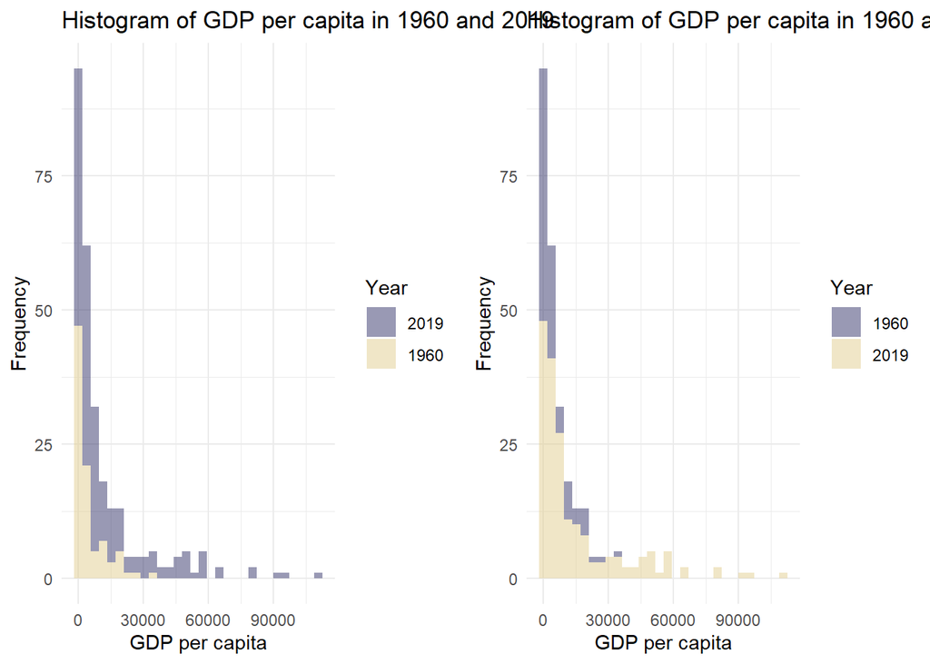

```r
library(dplyr)
library(ggplot2)

# Filter data for years 1960 and 2019
gdp_1960_2019 <- gapminder %>%
  filter(time %in% c(1960, 2019)) %>%
  select(region, time, GDP_PC)

# Create histogram for 1960 GDP per capita
hist_1960 <- ggplot(gdp_1960_2019, aes(x = GDP_PC, fill = factor(time == 1960))) +
  geom_histogram(alpha = 0.5, bins = 30) +
  scale_fill_manual(values = c("#33346a", "#e2ce90"), name = "Year",
                    labels = c("2019", "1960")) +
  labs(title = "Histogram of GDP per capita in 1960 and 2019", x = "GDP per capita",
       y = "Frequency") +
  theme_minimal()

# Create histogram for 2019 GDP per capita
hist_2019 <- ggplot(gdp_1960_2019, aes(x = GDP_PC, fill = factor(time == 2019))) +
  geom_histogram(alpha = 0.5, bins = 30) +
  scale_fill_manual(values = c("#33346a", "#e2ce90"), name = "Year",
                    labels = c("1960", "2019")) +
  labs(title = "Histogram of GDP per capita in 1960 and 2019", x = "GDP per capita",
       y = "Frequency") +
  theme_minimal()

# Combine the two histograms using cowplot package
library(cowplot)

combined_hist <- ggdraw() +
  draw_plot(hist_1960, 0, 0, 0.5, 1) +
  draw_plot(hist_2019, 0.5, 0, 0.5, 1)
# Display the combined histogram
combined_hist
```

7. (6pt) What was the ranking of US in terms of life expectancy in 1960 and in 2019? (When counting from top.) Hint: check out the function rank()! Hint2: 17 for 1960.

```r
library(dplyr)

# Compute the ranking of the US in terms of life expectancy in 1960
rank_1960 <- gapminder %>%
  filter(time == 1960) %>%
  filter(!is.na(lifeExpectancy)) %>%
  mutate(name == "United States", "United States of America") %>%
  arrange(desc(lifeExpectancy)) %>%
  mutate(rank = rank(-lifeExpectancy, ties.method = "min")) %>%
  filter(name == "United States of America") %>%
  select(rank)

# Compute the ranking of the US in terms of life expectancy in 2019
rank_2019 <- gapminder %>%
  filter(time == 2019) %>%
  filter(!is.na(lifeExpectancy)) %>%
  mutate(name == "United States of America") %>%
  arrange(desc(lifeExpectancy)) %>%
  mutate(rank = rank(-lifeExpectancy, ties.method = "min")) %>%
  filter(name == "United States of America") %>%
  select(rank)

rank_1960
```

```
##   rank
## 1   18
```

```r
rank_2019
```

```
##   rank
## 1   47
```

8. (6pt) If you did this correctly, then you noticed that US ranking has been falling quite a bit. But we also have more countries in 2019–what about the relative rank divided by the corresponding number of countries that have LE data in the corresponding year? Hint: 0.0904 for 1960.

```r
# Number of countries with LE data in 1960
n_countries_1960 <- gapminder %>%
  filter(!is.na(lifeExpectancy) & time == 1960) %>%
  summarize(n_countries = n()) %>%
  pull()

# Rank of US in 1960
rank_us_1960 <- gapminder %>%
  filter(!is.na(lifeExpectancy) & time == 1960) %>%
  select(name, lifeExpectancy) %>%
  arrange(desc(lifeExpectancy)) %>%
  mutate(rank = rank(-lifeExpectancy, ties.method = "first")) %>%
  filter(name == "United States of America") %>%
  pull(rank)

# Relative rank divided by number of countries with LE data in 1960
relative_rank_1960 <- rank_us_1960 / n_countries_1960

# Number of countries with LE data in 2019
n_countries_2019 <- gapminder %>%
  filter(!is.na(lifeExpectancy) & time == 2019) %>%
  summarize(n_countries = n()) %>%
  pull()

# Rank of US in 2019
rank_us_2019 <- gapminder %>%
  filter(!is.na(lifeExpectancy) & time == 2019) %>%
  select(name, lifeExpectancy) %>%
  arrange(desc(lifeExpectancy)) %>%
  mutate(rank = rank(-lifeExpectancy, ties.method = "first")) %>%
  filter(name == "United States of America") %>%
  pull(rank)

relative_rank_2019 <- rank_us_2019 / n_countries_2019
```

[output not shown]

*Time spend: Super struggle work, 6 hours or even more.*